# Week 5

Lindsay Anderson

April 25, 2017

## Hometown Bank Term Deposit Study

We have a target variable and it is binary - yes or no - so I will be applying multiple supervised learning techniques to detemrine the characteristics of customers that subscribe to term deposits.

## Looking at the Data

```r
setwd("C:/Users/clxa10/Desktop/Rockhurst/BIA6301")
getwd()
```

```
## [1] "C:/Users/clxa10/Desktop/Rockhurst/BIA6301"
```

```r
bank <-read.csv("bank-full.csv")
str(bank)
```

```
## 'data.frame':    45211 obs. of  17 variables:
##  $ age..number        : int  58 44 33 47 33 35 28 42 58 43 ...
##  $ job..category      : Factor w/ 12 levels "admin.","blue-collar",..: 5 10 3 2 12 5 5 3 6 10 ...
##  $ marital..category  : Factor w/ 3 levels "divorced","married",..: 2 3 2 2 3 2 3 1 2 3 ...
##  $ education..category: Factor w/ 4 levels "primary","secondary",..: 3 2 2 4 4 3 3 3 1 2 ...
##  $ default..category  : Factor w/ 2 levels "no","yes": 1 1 1 1 1 1 1 2 1 1 ...
##  $ balance..number    : int  2143 29 2 1506 1 231 447 2 121 593 ...
##  $ housing..category  : Factor w/ 2 levels "no","yes": 2 2 2 2 1 2 2 2 2 2 ...
##  $ loan..category     : Factor w/ 2 levels "no","yes": 1 1 2 1 1 1 2 1 1 1 ...
##  $ contact..category  : Factor w/ 3 levels "cellular","telephone",..: 3 3 3 3 3 3 3 3 3 3 ...
##  $ day..number        : int  5 5 5 5 5 5 5 5 5 5 ...
##  $ month..category    : Factor w/ 12 levels "apr","aug","dec",..: 9 9 9 9 9 9 9 9 9 9 ...
##  $ duration..number   : int  261 151 76 92 198 139 217 380 50 55 ...
##  $ campaign..number   : int  1 1 1 1 1 1 1 1 1 1 ...
##  $ pdays..number      : int  -1 -1 -1 -1 -1 -1 -1 -1 -1 -1 ...
##  $ previous..number   : int  0 0 0 0 0 0 0 0 0 0 ...
##  $ poutcome..category : Factor w/ 4 levels "failure","other",..: 4 4 4 4 4 4 4 4 4 4 ...
##  $ y..category        : Factor w/ 2 levels "no","yes": 1 1 1 1 1 1 1 1 1 1 ...
```

```r
table(bank$y..category) #5289 of the customers are term deposit subscribers while 39922 are not
```

```
##
##    no   yes
## 39922  5289
```

```r
summary(bank)
```

```
##   age..number        job..category  marital..category education..category
##  Min.   :18.00   blue-collar:9732   divorced: 5207    primary  : 6851
##  1st Qu.:33.00   management :9458   married :27214    secondary:23202
##  Median :39.00   technician :7597   single  :12790    tertiary :13301
##  Mean   :40.94   admin.     :5171                     unknown  : 1857
##  3rd Qu.:48.00   services   :4154
##  Max.   :95.00   retired    :2264
##                  (Other)    :6835
##  default..category balance..number  housing..category loan..category
##  no :44396         Min.   : -8019   no :20081         no :37967
##  yes:  815         1st Qu.:    72   yes:25130         yes: 7244
##                    Median :   448
##                    Mean   :  1362
##                    3rd Qu.:  1428
##                    Max.   :102127
##
##  contact..category  day..number    month..category duration..number
##  cellular :29285   Min.   : 1.00   may    :13766   Min.   :   0.0
##  telephone: 2906   1st Qu.: 8.00   jul    : 6895   1st Qu.: 103.0
##  unknown  :13020   Median :16.00   aug    : 6247   Median : 180.0
##                    Mean   :15.81   jun    : 5341   Mean   : 258.2
##                    3rd Qu.:21.00   nov    : 3970   3rd Qu.: 319.0
##                    Max.   :31.00   apr    : 2932   Max.   :4918.0
##                                    (Other): 6060
##  campaign..number pdays..number   previous..number   poutcome..category
##  Min.   : 1.000   Min.   : -1.0   Min.   :  0.0000   failure: 4901
##  1st Qu.: 1.000   1st Qu.: -1.0   1st Qu.:  0.0000   other  : 1840
##  Median : 2.000   Median : -1.0   Median :  0.0000   success: 1511
##  Mean   : 2.764   Mean   : 40.2   Mean   :  0.5803   unknown:36959
##  3rd Qu.: 3.000   3rd Qu.: -1.0   3rd Qu.:  0.0000
##  Max.   :63.000   Max.   :871.0   Max.   :275.0000
##
##  y..category
##  no :39922
##  yes: 5289
##
##
##
##
##
```

The target variable is shown in the summary above as y..category. There are 5,289 clients that are subscribed to a term deposit and 39,922 that are not.

## Logistic Regression

The first supervised learning method that I am going to apply is Logistic Regression. This method works to estimate the probability of a yes value for clients subscribing to term deposits.

```r
bank.model <- glm(y..category~., data=bank, family=binomial()) #Fit a logistic regression
summary(bank.model)
```

```
##
## Call:
## glm(formula = y..category ~ ., family = binomial(), data = bank)
##
## Deviance Residuals:
##     Min       1Q   Median       3Q      Max
## -5.7286  -0.3744  -0.2530  -0.1502   3.4288
##
## Coefficients:
##                                Estimate Std. Error z value Pr(>|z|)
## (Intercept)                  -2.536e+00  1.837e-01 -13.803  < 2e-16 ***
## age..number                   1.127e-04  2.205e-03   0.051 0.959233
## job..categoryblue-collar     -3.099e-01  7.267e-02  -4.264 2.01e-05 ***
## job..categoryentrepreneur    -3.571e-01  1.256e-01  -2.844 0.004455 **
## job..categoryhousemaid       -5.040e-01  1.365e-01  -3.693 0.000221 ***
## job..categorymanagement      -1.653e-01  7.329e-02  -2.255 0.024130 *
## job..categoryretired          2.524e-01  9.722e-02   2.596 0.009436 **
## job..categoryself-employed   -2.983e-01  1.120e-01  -2.664 0.007726 **
## job..categoryservices        -2.238e-01  8.406e-02  -2.662 0.007763 **
## job..categorystudent          3.821e-01  1.090e-01   3.505 0.000457 ***
## job..categorytechnician      -1.760e-01  6.893e-02  -2.554 0.010664 *
## job..categoryunemployed      -1.767e-01  1.116e-01  -1.583 0.113456
## job..categoryunknown         -3.133e-01  2.335e-01  -1.342 0.179656
## marital..categorymarried     -1.795e-01  5.891e-02  -3.046 0.002318 **
## marital..categorysingle       9.250e-02  6.726e-02   1.375 0.169066
## education..categorysecondary  1.835e-01  6.479e-02   2.833 0.004618 **
## education..categorytertiary   3.789e-01  7.532e-02   5.031 4.88e-07 ***
## education..categoryunknown    2.505e-01  1.039e-01   2.411 0.015915 *
## default..categoryyes         -1.668e-02  1.628e-01  -0.102 0.918407
## balance..number               1.283e-05  5.148e-06   2.493 0.012651 *
## housing..categoryyes         -6.754e-01  4.387e-02 -15.395  < 2e-16 ***
## loan..categoryyes            -4.254e-01  5.999e-02  -7.091 1.33e-12 ***
## contact..categorytelephone   -1.634e-01  7.519e-02  -2.173 0.029784 *
## contact..categoryunknown     -1.623e+00  7.317e-02 -22.184  < 2e-16 ***
## day..number                   9.969e-03  2.497e-03   3.993 6.53e-05 ***
## month..categoryaug           -6.939e-01  7.847e-02  -8.842  < 2e-16 ***
## month..categorydec            6.911e-01  1.767e-01   3.912 9.17e-05 ***
## month..categoryfeb           -1.473e-01  8.941e-02  -1.648 0.099427 .
## month..categoryjan           -1.262e+00  1.217e-01 -10.367  < 2e-16 ***
## month..categoryjul           -8.308e-01  7.740e-02 -10.733  < 2e-16 ***
```

[output cut: 8 more lines]

```
## pdays..number                -1.027e-04  3.061e-04  -0.335 0.737268
## previous..number              1.015e-02  6.503e-03   1.561 0.118476
## poutcome..categoryother       2.035e-01  8.986e-02   2.265 0.023543 *
## poutcome..categorysuccess     2.291e+00  8.235e-02  27.821  < 2e-16 ***
## poutcome..categoryunknown    -9.179e-02  9.347e-02  -0.982 0.326093
## ---
## Signif. codes:  0 '***' 0.001 '**' 0.01 '*' 0.05 '.' 0.1 ' ' 1
##
## (Dispersion parameter for binomial family taken to be 1)
##
##     Null deviance: 32631  on 45210  degrees of freedom
## Residual deviance: 21562  on 45168  degrees of freedom
## AIC: 21648
##
## Number of Fisher Scoring iterations: 6
```

```r
exp(cbind(Odds_Ratio=coef(bank.model)))
```

```
##                              Odds_Ratio
## (Intercept)                  0.07921118
## age..number                  1.00011272
## job..categoryblue-collar     0.73354041
## job..categoryentrepreneur    0.69969989
## job..categoryhousemaid       0.60410838
## job..categorymanagement      0.84765765
## job..categoryretired         1.28706269
## job..categoryself-employed   0.74205191
## job..categoryservices        0.79947733
## job..categorystudent         1.46541095
## job..categorytechnician      0.83860411
## job..categoryunemployed      0.83802016
## job..categoryunknown         0.73105661
## marital..categorymarried     0.83572682
## marital..categorysingle      1.09691056
## education..categorysecondary 1.20144892
## education..categorytertiary  1.46073758
## education..categoryunknown   1.28464040
## default..categoryyes         0.98345715
## balance..number              1.00001284
## housing..categoryyes         0.50896077
## loan..categoryyes            0.65352685
## contact..categorytelephone   0.84927322
## contact..categoryunknown     0.19726311
## day..number                  1.01001878
## month..categoryaug           0.49961996
## month..categorydec           1.99595838
## month..categoryfeb           0.86301696
## month..categoryjan           0.28316690
## month..categoryjul           0.43570251
## month..categoryjun           1.57400386
## month..categorymar           4.90321221
## month..categorymay           0.67091594
## month..categorynov           0.41753015
## month..categoryoct           2.41436771
## month..categorysep           2.39661674
## duration..number             1.00420250
## campaign..number             0.91321697
## pdays..number                0.99989732
## previous..number             1.01020406
## poutcome..categoryother      1.22565868
## poutcome..categorysuccess    9.88537129
## poutcome..categoryunknown    0.91229351
```

## Is the Logistic Regression Model Statistically Significant?

```r
anova(bank.model,test="Chisq")
```

```
## Analysis of Deviance Table
##
## Model: binomial, link: logit
##
## Response: y..category
##
## Terms added sequentially (first to last)
##
##
##                     Df Deviance Resid. Df Resid. Dev  Pr(>Chi)
## NULL                                45210      32631
## age..number          1     28.2     45209      32603 1.074e-07 ***
## job..category       11    720.2     45198      31883 < 2.2e-16 ***
## marital..category    2    156.6     45196      31726 < 2.2e-16 ***
## education..category  3    103.8     45193      31622 < 2.2e-16 ***
## default..category    1     18.9     45192      31603 1.362e-05 ***
## balance..number      1     53.0     45191      31550 3.262e-13 ***
## housing..category    1    525.0     45190      31025 < 2.2e-16 ***
## loan..category       1    138.2     45189      30887 < 2.2e-16 ***
## contact..category    2    798.7     45187      30088 < 2.2e-16 ***
## day..number          1     54.9     45186      30033 1.270e-13 ***
## month..category     11   1367.2     45175      28666 < 2.2e-16 ***
## duration..number     1   5612.5     45174      23054 < 2.2e-16 ***
## campaign..number     1    139.4     45173      22914 < 2.2e-16 ***
## pdays..number        1    133.5     45172      22781 < 2.2e-16 ***
## previous..number     1     51.9     45171      22729 5.734e-13 ***
## poutcome..category   3   1166.7     45168      21562 < 2.2e-16 ***
## ---
## Signif. codes:  0 '***' 0.001 '**' 0.01 '*' 0.05 '.' 0.1 ' ' 1
```

## Logistic Regression with Modified Variables

```r
bank.model2 <- glm(y..category~age..number+housing..category+loan..category+contact..category+day..number+month..category+duration..number+campaign..number+pdays..number+previous..number+poutcome..category, data=bank, family=binomial()) #Fit a logistic regression
summary(bank.model2)
```

```
##
## Call:
## glm(formula = y..category ~ age..number + housing..category +
##     loan..category + contact..category + day..number + month..category +
##     duration..number + campaign..number + pdays..number + previous..number +
##     poutcome..category, family = binomial(), data = bank)
##
## Deviance Residuals:
##     Min       1Q   Median       3Q      Max
## -5.6726  -0.3785  -0.2605  -0.1518   3.4131
##
## Coefficients:
##                              Estimate Std. Error z value Pr(>|z|)
## (Intercept)                -2.243e+00  1.350e-01 -16.614  < 2e-16 ***
## age..number                -4.217e-03  1.587e-03  -2.658  0.00787 **
## housing..categoryyes       -7.726e-01  4.283e-02 -18.039  < 2e-16 ***
## loan..categoryyes          -4.776e-01  5.936e-02  -8.046 8.55e-16 ***
## contact..categorytelephone -1.425e-01  7.386e-02  -1.929  0.05369 .
## contact..categoryunknown   -1.706e+00  7.298e-02 -23.376  < 2e-16 ***
## day..number                 1.094e-02  2.494e-03   4.385 1.16e-05 ***
## month..categoryaug         -7.024e-01  7.754e-02  -9.059  < 2e-16 ***
## month..categorydec          7.970e-01  1.766e-01   4.514 6.36e-06 ***
## month..categoryfeb         -1.227e-01  8.873e-02  -1.383  0.16661
## month..categoryjan         -1.263e+00  1.210e-01 -10.438  < 2e-16 ***
## month..categoryjul         -8.743e-01  7.690e-02 -11.370  < 2e-16 ***
## month..categoryjun          4.757e-01  9.360e-02   5.083 3.72e-07 ***
## month..categorymar          1.706e+00  1.192e-01  14.317  < 2e-16 ***
## month..categorymay         -3.845e-01  7.178e-02  -5.357 8.46e-08 ***
## month..categorynov         -8.917e-01  8.379e-02 -10.642  < 2e-16 ***
## month..categoryoct          9.631e-01  1.075e-01   8.957  < 2e-16 ***
## month..categorysep          9.819e-01  1.190e-01   8.252  < 2e-16 ***
## duration..number            4.167e-03  6.395e-05  65.167  < 2e-16 ***
## campaign..number           -9.598e-02  1.018e-02  -9.431  < 2e-16 ***
## pdays..number              -2.434e-04  3.059e-04  -0.796  0.42622
## previous..number            1.063e-02  6.577e-03   1.616  0.10609
## poutcome..categoryother     2.142e-01  8.936e-02   2.397  0.01653 *
## poutcome..categorysuccess   2.323e+00  8.214e-02  28.279  < 2e-16 ***
## poutcome..categoryunknown  -1.202e-01  9.347e-02  -1.286  0.19841
## ---
## Signif. codes:  0 '***' 0.001 '**' 0.01 '*' 0.05 '.' 0.1 ' ' 1
##
## (Dispersion parameter for binomial family taken to be 1)
##
##     Null deviance: 32631  on 45210  degrees of freedom
## Residual deviance: 21785  on 45186  degrees of freedom
## AIC: 21835
##
## Number of Fisher Scoring iterations: 6
```

```r
exp(cbind(Odds_Ratio=coef(bank.model)))
```

```
##                              Odds_Ratio
## (Intercept)                  0.07921118
## age..number                  1.00011272
## job..categoryblue-collar     0.73354041
## job..categoryentrepreneur    0.69969989
## job..categoryhousemaid       0.60410838
## job..categorymanagement      0.84765765
## job..categoryretired         1.28706269
## job..categoryself-employed   0.74205191
## job..categoryservices        0.79947733
## job..categorystudent         1.46541095
## job..categorytechnician      0.83860411
## job..categoryunemployed      0.83802016
## job..categoryunknown         0.73105661
## marital..categorymarried     0.83572682
## marital..categorysingle      1.09691056
## education..categorysecondary 1.20144892
## education..categorytertiary  1.46073758
## education..categoryunknown   1.28464040
## default..categoryyes         0.98345715
## balance..number              1.00001284
## housing..categoryyes         0.50896077
## loan..categoryyes            0.65352685
## contact..categorytelephone   0.84927322
## contact..categoryunknown     0.19726311
## day..number                  1.01001878
## month..categoryaug           0.49961996
## month..categorydec           1.99595838
## month..categoryfeb           0.86301696
## month..categoryjan           0.28316690
## month..categoryjul           0.43570251
## month..categoryjun           1.57400386
## month..categorymar           4.90321221
## month..categorymay           0.67091594
## month..categorynov           0.41753015
## month..categoryoct           2.41436771
## month..categorysep           2.39661674
## duration..number             1.00420250
## campaign..number             0.91321697
## pdays..number                0.99989732
## previous..number             1.01020406
## poutcome..categoryother      1.22565868
## poutcome..categorysuccess    9.88537129
## poutcome..categoryunknown    0.91229351
```

The variables that are showing to not be statistically significant are pdays number and previous number. I will adjust the model again to remove these variables.

## Third Logistic Model

```r
bank.model3 <- glm(y..category~age..number+housing..category+loan..category+contact..category+day..number+month..category+duration..number+campaign..number+poutcome..category, data=bank, family=binomial()) #Fit a logistic regression
summary(bank.model3)
```

```
##
## Call:
## glm(formula = y..category ~ age..number + housing..category +
##     loan..category + contact..category + day..number + month..category +
##     duration..number + campaign..number + poutcome..category,
##     family = binomial(), data = bank)
##
## Deviance Residuals:
##     Min       1Q   Median       3Q      Max
## -5.6733  -0.3787  -0.2605  -0.1517   3.4121
##
## Coefficients:
##                              Estimate Std. Error z value Pr(>|z|)
## (Intercept)                -2.272e+00  1.125e-01 -20.196  < 2e-16 ***
## age..number                -4.204e-03  1.587e-03  -2.650  0.00805 **
## housing..categoryyes       -7.743e-01  4.266e-02 -18.148  < 2e-16 ***
## loan..categoryyes          -4.774e-01  5.936e-02  -8.043 8.78e-16 ***
## contact..categorytelephone -1.416e-01  7.385e-02  -1.917  0.05525 .
## contact..categoryunknown   -1.704e+00  7.297e-02 -23.353  < 2e-16 ***
## day..number                 1.089e-02  2.495e-03   4.366 1.26e-05 ***
## month..categoryaug         -6.982e-01  7.749e-02  -9.011  < 2e-16 ***
## month..categorydec          8.012e-01  1.767e-01   4.535 5.76e-06 ***
## month..categoryfeb         -1.164e-01  8.859e-02  -1.314  0.18890
## month..categoryjan         -1.257e+00  1.209e-01 -10.392  < 2e-16 ***
## month..categoryjul         -8.713e-01  7.689e-02 -11.333  < 2e-16 ***
## month..categoryjun          4.795e-01  9.357e-02   5.125 2.98e-07 ***
## month..categorymar          1.710e+00  1.191e-01  14.362  < 2e-16 ***
## month..categorymay         -3.855e-01  7.171e-02  -5.376 7.61e-08 ***
## month..categorynov         -8.833e-01  8.334e-02 -10.599  < 2e-16 ***
## month..categoryoct          9.695e-01  1.074e-01   9.025  < 2e-16 ***
## month..categorysep          9.850e-01  1.189e-01   8.282  < 2e-16 ***
## duration..number            4.167e-03  6.395e-05  65.164  < 2e-16 ***
## campaign..number           -9.559e-02  1.017e-02  -9.402  < 2e-16 ***
## poutcome..categoryother     2.301e-01  8.886e-02   2.589  0.00961 **
## poutcome..categorysuccess   2.341e+00  7.951e-02  29.444  < 2e-16 ***
## poutcome..categoryunknown  -9.442e-02  5.729e-02  -1.648  0.09934 .
## ---
## Signif. codes:  0 '***' 0.001 '**' 0.01 '*' 0.05 '.' 0.1 ' ' 1
##
## (Dispersion parameter for binomial family taken to be 1)
##
##     Null deviance: 32631  on 45210  degrees of freedom
## Residual deviance: 21788  on 45188  degrees of freedom
## AIC: 21834
##
## Number of Fisher Scoring iterations: 6
```

```r
exp(cbind(Odds_Ratio=coef(bank.model3)))
```

```
##                            Odds_Ratio
## (Intercept)                 0.1031184
## age..number                 0.9958044
## housing..categoryyes        0.4610374
## loan..categoryyes           0.6203697
## contact..categorytelephone  0.8680046
## contact..categoryunknown    0.1819315
## day..number                 1.0109511
## month..categoryaug          0.4974575
## month..categorydec          2.2281548
## month..categoryfeb          0.8901245
## month..categoryjan          0.2845513
## month..categoryjul          0.4183987
## month..categoryjun          1.6152376
## month..categorymar          5.5305987
## month..categorymay          0.6800932
## month..categorynov          0.4134083
## month..categoryoct          2.6367298
## month..categorysep          2.6777717
## duration..number            1.0041757
## campaign..number            0.9088335
## poutcome..categoryother     1.2587295
## poutcome..categorysuccess  10.3937523
## poutcome..categoryunknown   0.9099024
```

The most important variable identified by the logistic regression model is the poutcome category of success. When the outcome of the prior marketing campaign is a success, the odds of the client subscribing to a term deposit are 10 times more likely than if the prior campaign was a failure. The next most important variable is the month in which the customers were contacted. Customers in March are nearly 6 times more likely to subscribe to a term deposit than those in April.

# Decision Tree Model

## Creating a Training and Testing Set

The logistic regression model points out many variables that may affect a client’s decision to subscribe to a term deposit. An easier way to view this time of data and narrow down the results is to use a decision tree model.

```r
set.seed(123)
bank_rand <- bank[order(runif(40000)), ]
bank_train <- bank_rand[1:32000, ] #Training data set; 32000 observations
bank_test  <-bank_rand[32001:40000, ]
```

Above I am splitting the data set into a training set and a validation set. The training set will be used to train the model and the validation set will be used to run through the model to evaluate the performance of it.

## Summary of the Decision Tree

```r
library(rpart)
set.seed(123)
bank_rpart <- rpart(bank_train$y..category~., method="class", parms = list(split="gini"), data=bank_train)
#summary(bank_rpart) - the summary results are long, decision trees are better visualized
```

## Plot of the Decision Tree

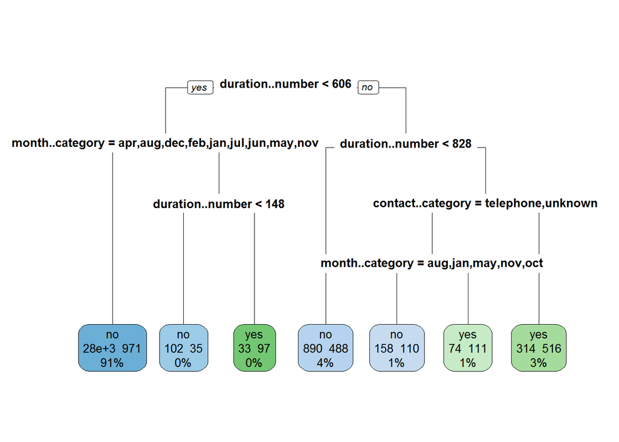

```r
library(rpart.plot)
rpart.plot(bank_rpart, type=0, extra=101)
```

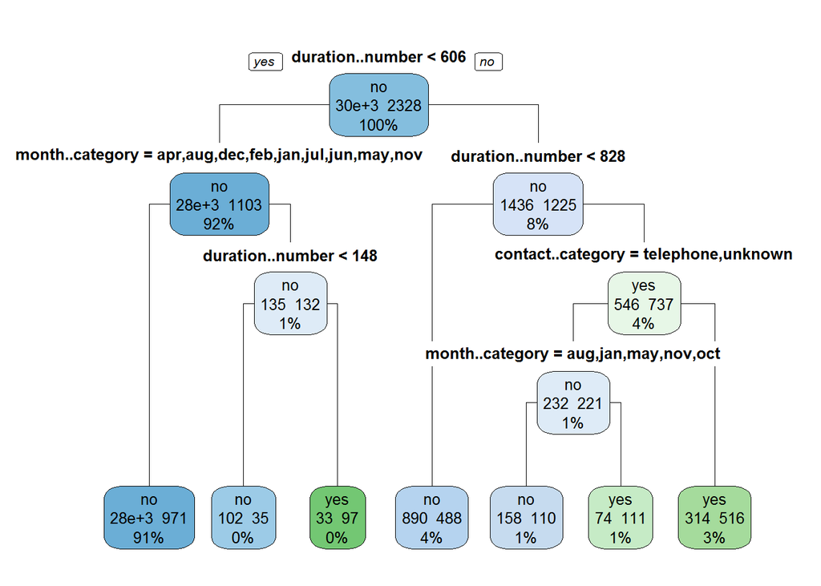

```r
rpart.plot(bank_rpart, type=1, extra=101)

library(party)
```

```r
library(partykit)
```

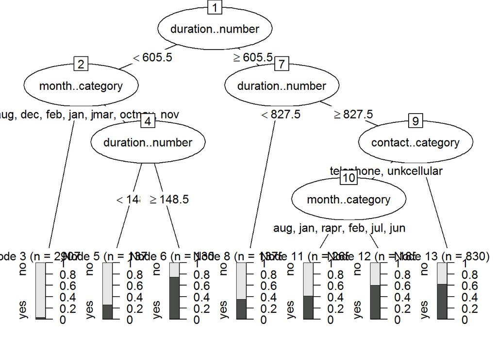

```r
bank_party<-as.party(bank_rpart)
plot(bank_party)
```

```r
cptable<-printcp(bank_rpart)
```

```
##
## Classification tree:
## rpart(formula = bank_train$y..category ~ ., data = bank_train,
##     method = "class", parms = list(split = "gini"))
##
## Variables actually used in tree construction:
## [1] contact..category duration..number  month..category
##
## Root node error: 2328/32000 = 0.07275
##
## n= 32000
##
##         CP nsplit rel error  xerror     xstd
## 1 0.041022      0   1.00000 1.00000 0.019958
## 2 0.013746      2   0.91796 0.91796 0.019183
## 3 0.010309      4   0.89046 0.90593 0.019066
## 4 0.010000      6   0.86985 0.88789 0.018888
```

```r
cptable
```

```
##           CP nsplit rel error    xerror       xstd
## 1 0.04102234      0 1.0000000 1.0000000 0.01995754
## 2 0.01374570      2 0.9179553 0.9179553 0.01918276
## 3 0.01030928      4 0.8904639 0.9059278 0.01906560
## 4 0.01000000      6 0.8698454 0.8878866 0.01888806
```

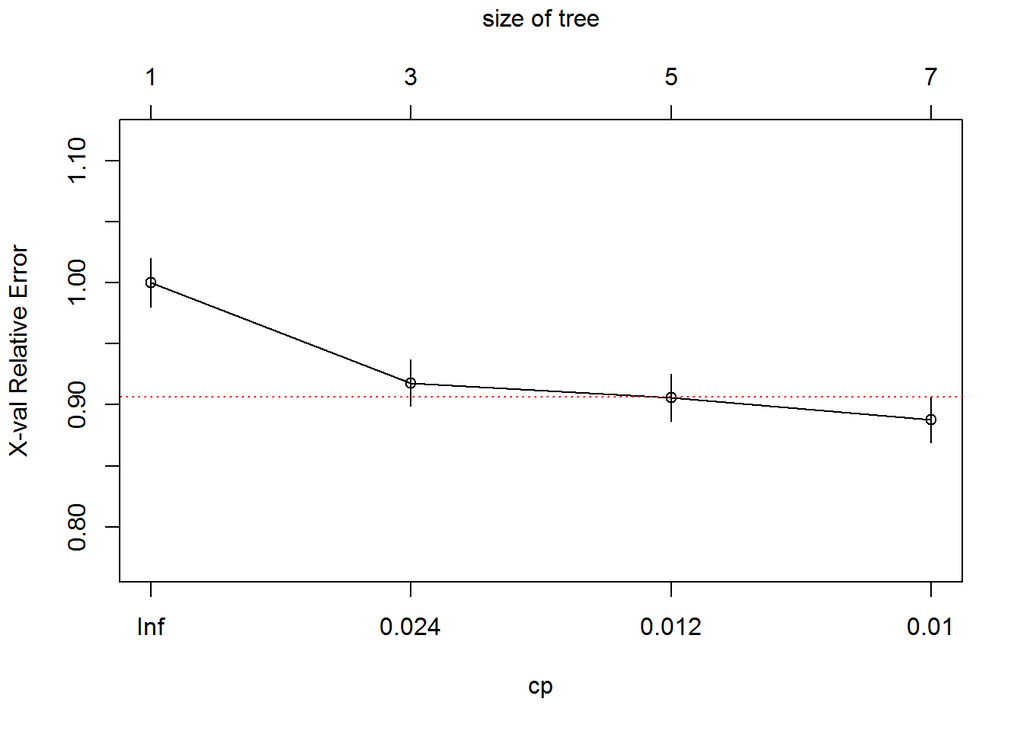

```r
plotcp(bank_rpart, minline=TRUE, col="red")
```

The decision tree above has identified the below variables as being predictors of people who subscribe to term deposits: - Duration of the previous time the customer was contacted - The month of the contact - The type of contact that was made (telephone, unknown, or cellular)

```r
library(caret)
actual <- bank_test$y..category
predicted <- predict(bank_rpart, bank_test, type="class")
results.matrix <- confusionMatrix(predicted, actual, positive="yes")
print(results.matrix)
```

```
## Confusion Matrix and Statistics
##
##           Reference
## Prediction   no  yes
##        no  7308  414
##        yes  124  154
##
##                Accuracy : 0.9328
##                  95% CI : (0.927, 0.9381)
##     No Information Rate : 0.929
##     P-Value [Acc > NIR] : 0.0988
##
##                   Kappa : 0.3329
##  Mcnemar's Test P-Value : <2e-16
##
##             Sensitivity : 0.27113
##             Specificity : 0.98332
##          Pos Pred Value : 0.55396
##          Neg Pred Value : 0.94639
##              Prevalence : 0.07100
##          Detection Rate : 0.01925
##    Detection Prevalence : 0.03475
##       Balanced Accuracy : 0.62722
##
##        'Positive' Class : yes
##
```

The model accuracy is 93% but the ability to predict the clients that subscribed is only 27%. I am going to try to prune the tree and see if I can get better results.

## Pruned Decision Tree

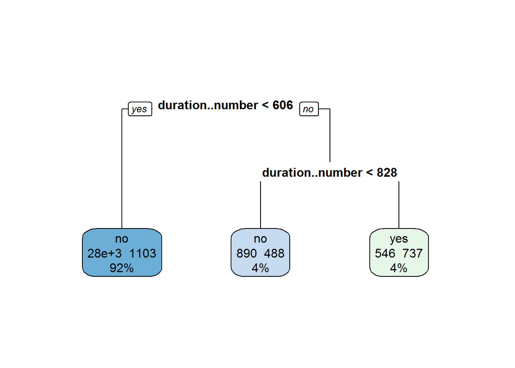

```r
Pruned_bank_rpart <- prune(bank_rpart, cp=0.024)

rpart.plot(Pruned_bank_rpart, type=0, extra=101)
```

The pruned tree shows that the only variable that is significant is the duration of the previous contact made with the customer. I would like to test if our ability to predict customers who subscribe to term deposits has increased.

```r
actual <- bank_test$y..category
predicted <- predict(Pruned_bank_rpart, bank_test, type="class")
pruned_results.matrix <- confusionMatrix(predicted, actual, positive="yes")
print(pruned_results.matrix)
```

```
## Confusion Matrix and Statistics
##
##           Reference
## Prediction   no  yes
##        no  7292  391
##        yes  140  177
##
##                Accuracy : 0.9336
##                  95% CI : (0.9279, 0.939)
##     No Information Rate : 0.929
##     P-Value [Acc > NIR] : 0.05493
##
##                   Kappa : 0.3678
##  Mcnemar's Test P-Value : < 2e-16
##
##             Sensitivity : 0.31162
##             Specificity : 0.98116
##          Pos Pred Value : 0.55836
##          Neg Pred Value : 0.94911
##              Prevalence : 0.07100
##          Detection Rate : 0.02212
##    Detection Prevalence : 0.03963
##       Balanced Accuracy : 0.64639
##
##        'Positive' Class : yes
##
```

Our ability to predict customers that subscribed to term deposits has increased but only to 31%. I’d like to get this a bit higher so I am going to try another decision tree using the information gain approach.

## Using Information Gain Method

```r
bank_infogain <- rpart(bank_train$y..category~., method="class", parms = list(split="information"), data=bank_train)
summary(bank_infogain)
```

```
## Call:
## rpart(formula = bank_train$y..category ~ ., data = bank_train,
##     method = "class", parms = list(split = "information"))
##   n= 32000
##
##           CP nsplit rel error    xerror       xstd
## 1 0.04102234      0 1.0000000 1.0000000 0.01995754
## 2 0.01030928      2 0.9179553 0.9235395 0.01923683
## 3 0.01000000      4 0.8973368 0.9222509 0.01922437
##
## Variable importance
##  duration..number   month..category contact..category
##                98                 1                 1
##
## Node number 1: 32000 observations,    complexity param=0.04102234
##   predicted class=no   expected loss=0.07275  P(node) =1
##     class counts: 29672  2328
##    probabilities: 0.927 0.073
##   left son=2 (27859 obs) right son=3 (4141 obs)
##   Primary splits:
##       duration..number   < 474.5   to the left,   improve=1978.14600, (0 missing)
##       month..category    splits as  RLLRLLLRLLR-, improve= 257.75040, (0 missing)
##       contact..category  splits as  RRL,          improve= 141.68140, (0 missing)
##       poutcome..category splits as  LLRL,         improve= 103.82020, (0 missing)
##       age..number        < 60.5    to the left,   improve=  71.52689, (0 missing)
##
## Node number 2: 27859 observations
##   predicted class=no   expected loss=0.02882372  P(node) =0.8705938
##     class counts: 27056   803
##    probabilities: 0.971 0.029
##
## Node number 3: 4141 observations,    complexity param=0.04102234
##   predicted class=no   expected loss=0.3682685  P(node) =0.1294063
##     class counts:  2616  1525
##    probabilities: 0.632 0.368
##   left son=6 (2858 obs) right son=7 (1283 obs)
##   Primary splits:
##       duration..number   < 827.5   to the left,   improve=166.88510, (0 missing)
##       contact..category  splits as  RLL,          improve= 37.56030, (0 missing)
##       marital..category  splits as  RLR,          improve= 15.78744, (0 missing)
```

[output cut: 47 more lines]

```
##
## Node number 15: 830 observations
##   predicted class=yes  expected loss=0.3783133  P(node) =0.0259375
##     class counts:   314   516
##    probabilities: 0.378 0.622
##
## Node number 28: 268 observations
##   predicted class=no   expected loss=0.4104478  P(node) =0.008375
##     class counts:   158   110
##    probabilities: 0.590 0.410
##
## Node number 29: 185 observations
##   predicted class=yes  expected loss=0.4  P(node) =0.00578125
##     class counts:    74   111
##    probabilities: 0.400 0.600
```

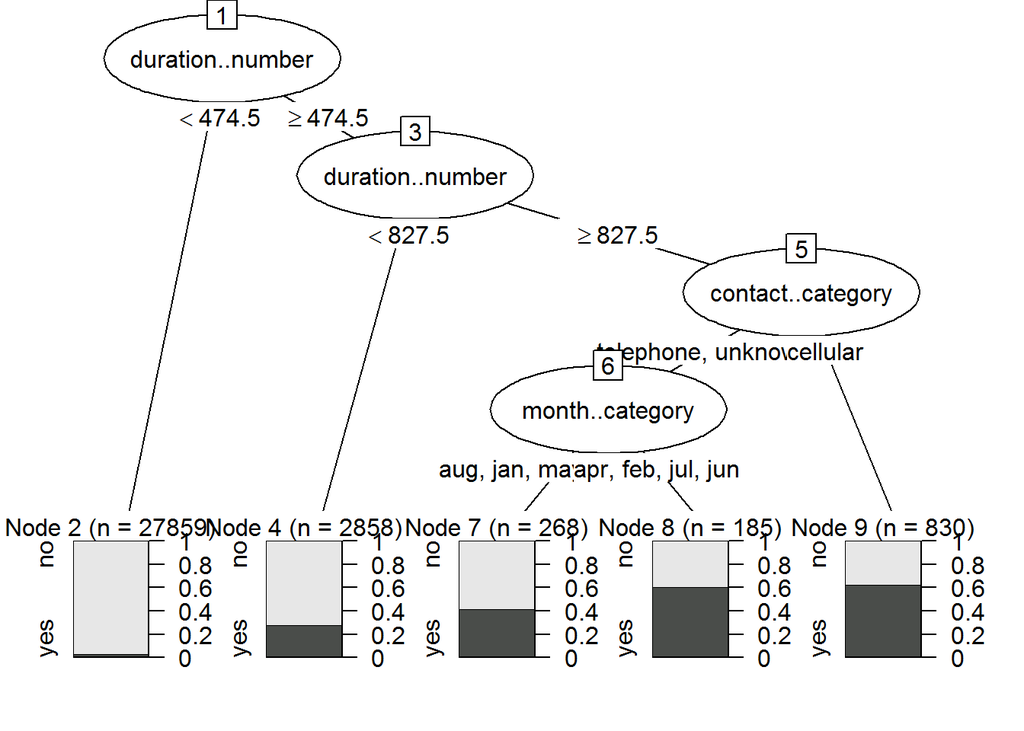

```r
bank_infogain_party<-as.party(bank_infogain)
plot(bank_infogain_party)
```

```r
#Prune the Tree
cptable<-printcp(bank_infogain)
```

```
##
## Classification tree:
## rpart(formula = bank_train$y..category ~ ., data = bank_train,
##     method = "class", parms = list(split = "information"))
##
## Variables actually used in tree construction:
## [1] contact..category duration..number  month..category
##
## Root node error: 2328/32000 = 0.07275
##
## n= 32000
##
##         CP nsplit rel error  xerror     xstd
## 1 0.041022      0   1.00000 1.00000 0.019958
## 2 0.010309      2   0.91796 0.92354 0.019237
## 3 0.010000      4   0.89734 0.92225 0.019224
```

```r
cptable
```

```
##           CP nsplit rel error    xerror       xstd
## 1 0.04102234      0 1.0000000 1.0000000 0.01995754
## 2 0.01030928      2 0.9179553 0.9235395 0.01923683
## 3 0.01000000      4 0.8973368 0.9222509 0.01922437
```

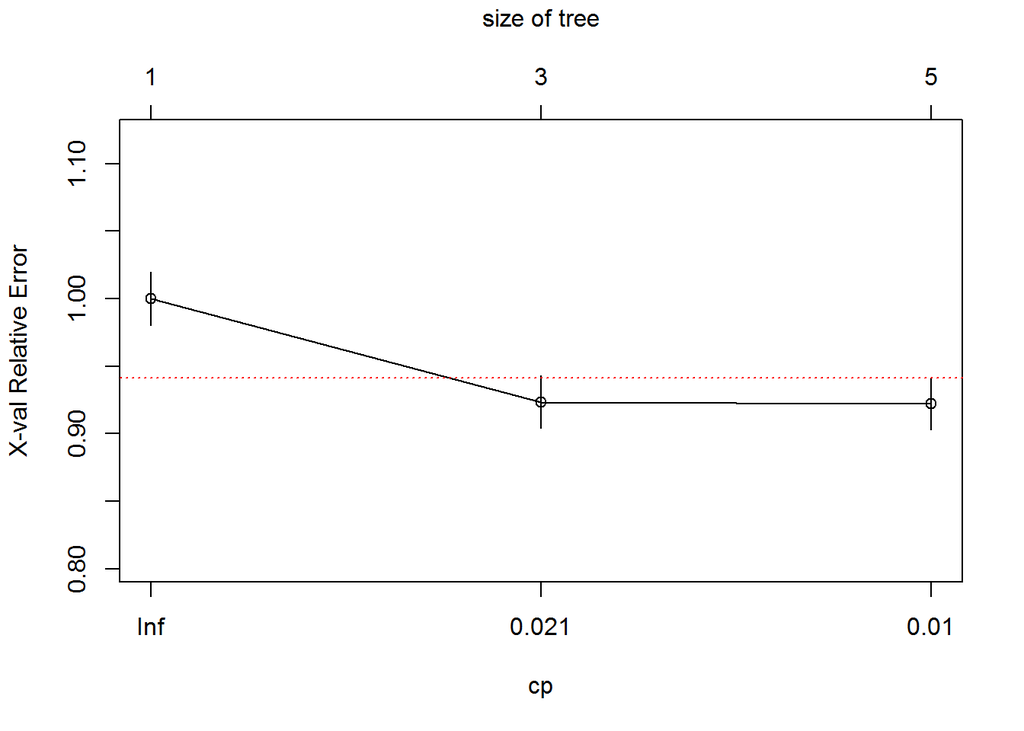

```r
plotcp(bank_infogain, minline=TRUE, col="red")
```

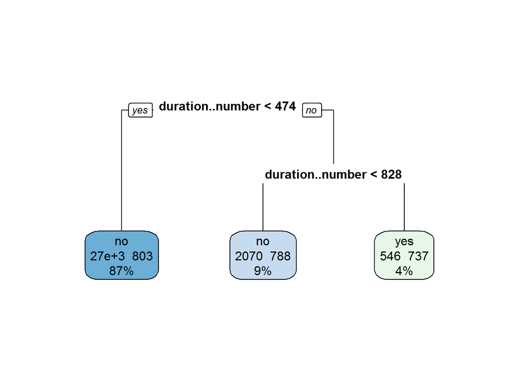

```r
Pruned_bank_infogain <- prune(bank_infogain, cp=0.021)
#summary(Pruned_bank_infogain)
rpart.plot(Pruned_bank_infogain, type=0, extra=101)
```

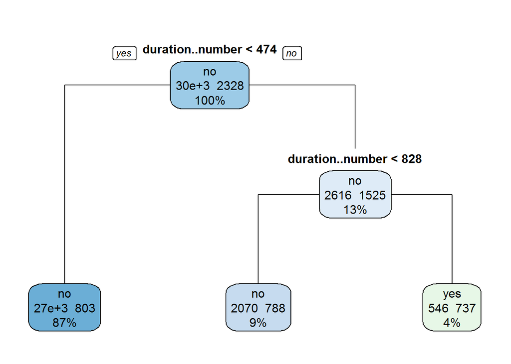

```r
rpart.plot(Pruned_bank_infogain, type=1, extra=101)
```

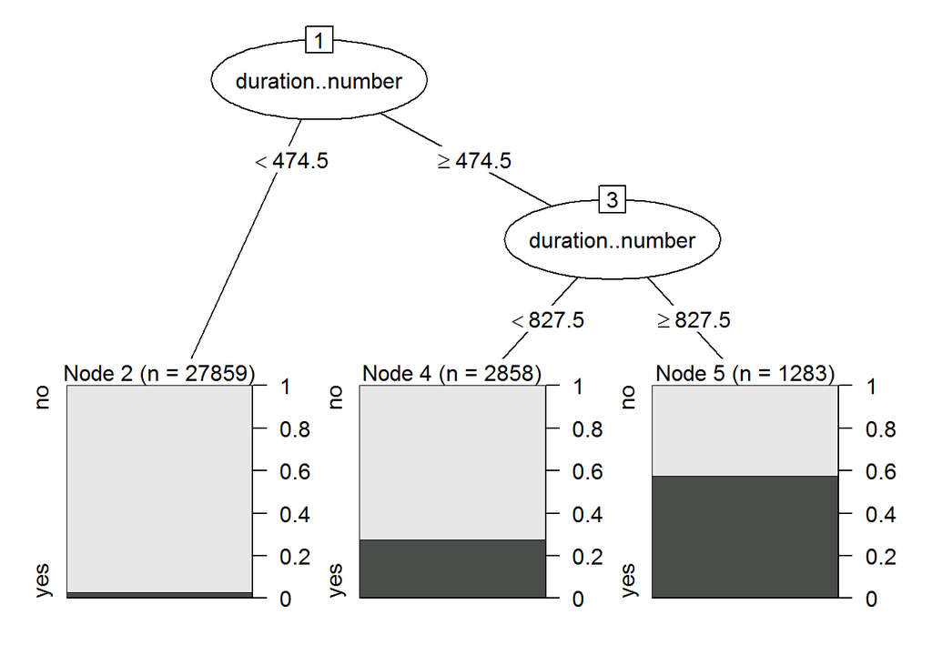

```r
Pruned_bank_party<-as.party(Pruned_bank_infogain)
plot(Pruned_bank_party)
```

Similarly the decision tree using information gain found that the duration of the previous contact to the customer is the most significant predictor.

## Confusion Matrix for the Info Gain Decision Tree

```r
actual_info <- bank_test$y..category
predicted_info <- predict(bank_infogain, bank_test, type="class")
results.matrix_info <- confusionMatrix(predicted_info, actual_info, positive="yes")
print(results.matrix_info)
```

```
## Confusion Matrix and Statistics
##
##           Reference
## Prediction   no  yes
##        no  7318  429
##        yes  114  139
##
##                Accuracy : 0.9321
##                  95% CI : (0.9264, 0.9375)
##     No Information Rate : 0.929
##     P-Value [Acc > NIR] : 0.1429
##
##                   Kappa : 0.3083
##  Mcnemar's Test P-Value : <2e-16
##
##             Sensitivity : 0.24472
##             Specificity : 0.98466
##          Pos Pred Value : 0.54941
##          Neg Pred Value : 0.94462
##              Prevalence : 0.07100
##          Detection Rate : 0.01738
##    Detection Prevalence : 0.03163
##       Balanced Accuracy : 0.61469
##
##        'Positive' Class : yes
##
```

The model is still only able to predict 24% of the customers that subscribe to term deposits.

# Pruned Model Accuracy

```r
actual_info_pruned <- bank_test$y..category
predicted_info_pruned <- predict(Pruned_bank_infogain, bank_test, type="class")
pruned_results.matrix_info <- confusionMatrix(predicted_info_pruned, actual_info_pruned, positive="yes")
print(pruned_results.matrix_info)
```

```
## Confusion Matrix and Statistics
##
##           Reference
## Prediction   no  yes
##        no  7292  391
##        yes  140  177
##
##                Accuracy : 0.9336
##                  95% CI : (0.9279, 0.939)
##     No Information Rate : 0.929
##     P-Value [Acc > NIR] : 0.05493
##
##                   Kappa : 0.3678
##  Mcnemar's Test P-Value : < 2e-16
##
##             Sensitivity : 0.31162
##             Specificity : 0.98116
##          Pos Pred Value : 0.55836
##          Neg Pred Value : 0.94911
##              Prevalence : 0.07100
##          Detection Rate : 0.02212
##    Detection Prevalence : 0.03963
##       Balanced Accuracy : 0.64639
##
##        'Positive' Class : yes
##
```

Similar to the last tree using the Gini index, the ability to predict customers that subscribe to term deposits is 31%. The most important variable in this prediction is the duration of the previous call to the customer.

### Using the Caret Package to Train & Validate Models

```r
set.seed(123)
trainIndex <- createDataPartition(bank$y..category, p = .8,list = FALSE,times = 1)
bank_train_caret <- bank[ trainIndex,]
bank_validate_caret <- bank[ -trainIndex,]
```

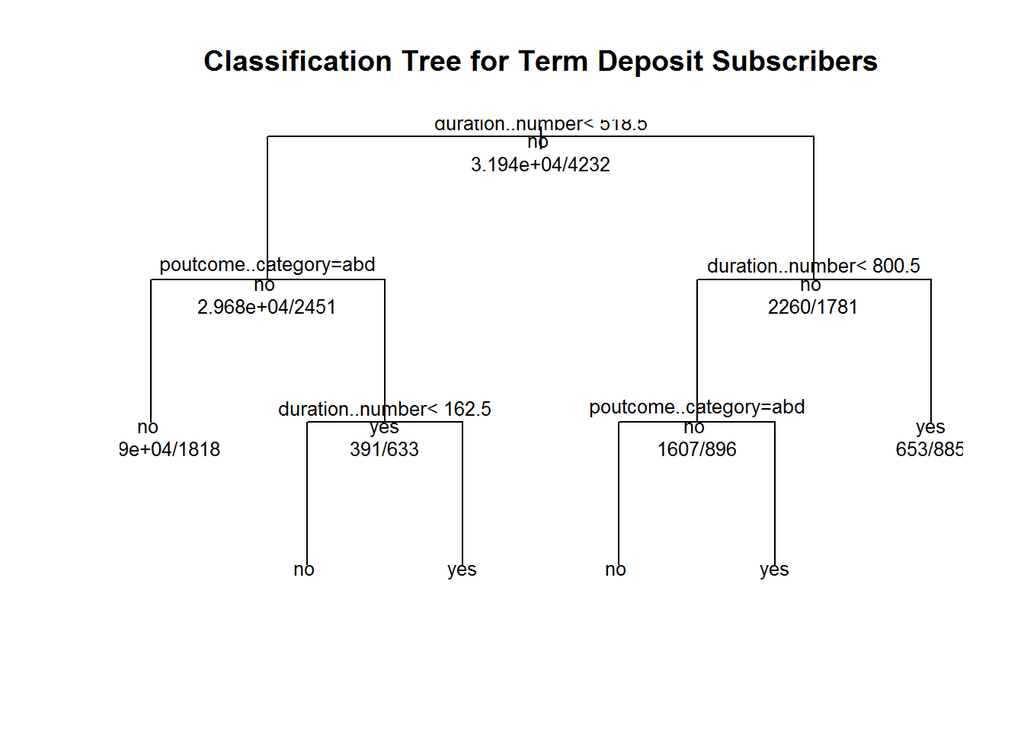

```r
bank_rpart_caret <- rpart(y..category~., method="class", parms = list(split="gini"), data=bank_train_caret)

plot(bank_rpart_caret, uniform=TRUE, main="Classification Tree for Term Deposit Subscribers")
text(bank_rpart_caret, use.n=TRUE, all=TRUE, cex=0.8)
```

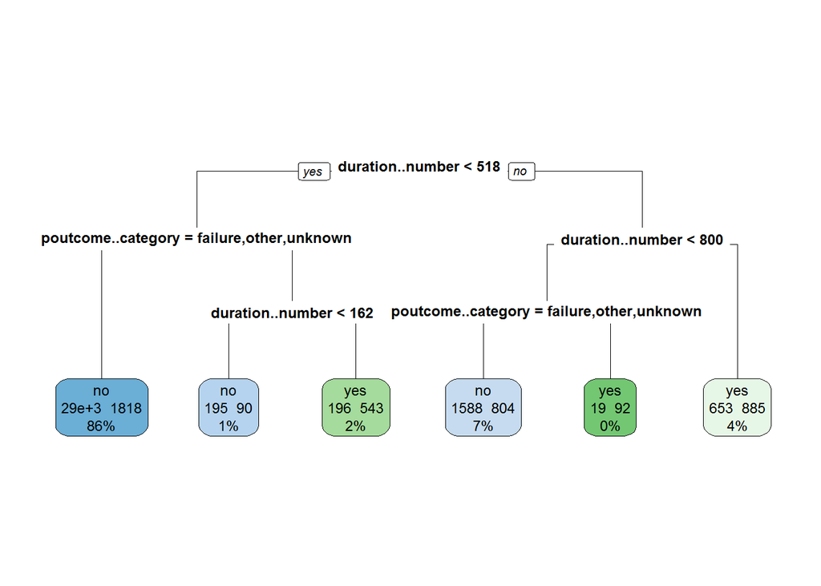

```r
rpart.plot(bank_rpart_caret, type=0, extra=101)
```

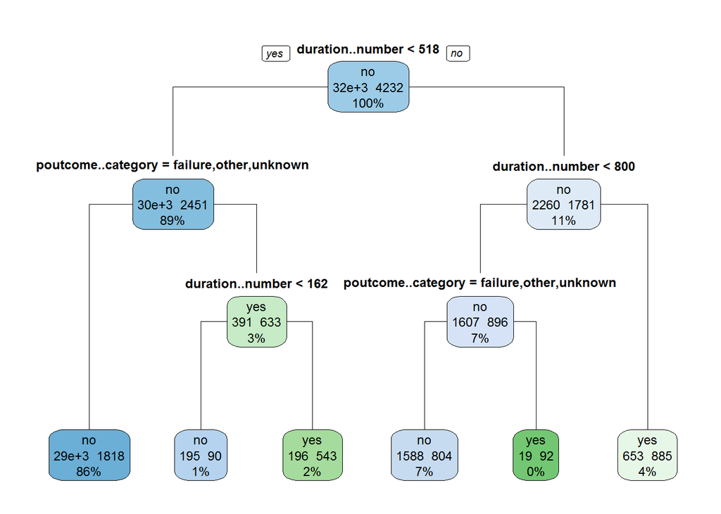

```r
rpart.plot(bank_rpart_caret, type=1, extra=101)
```

```r
actual <- bank_validate_caret$y..category
predicted <- predict(bank_rpart_caret, bank_validate_caret, type="class")
results.matrix.caret <- confusionMatrix(predicted, actual, positive="yes")
print(results.matrix.caret)
```

```
## Confusion Matrix and Statistics
##
##           Reference
## Prediction   no  yes
##        no  7755  672
##        yes  229  385
##
##                Accuracy : 0.9003
##                  95% CI : (0.894, 0.9064)
##     No Information Rate : 0.8831
##     P-Value [Acc > NIR] : 9.899e-08
##
##                   Kappa : 0.4101
##  Mcnemar's Test P-Value : < 2.2e-16
##
##             Sensitivity : 0.36424
##             Specificity : 0.97132
##          Pos Pred Value : 0.62704
##          Neg Pred Value : 0.92026
##              Prevalence : 0.11691
##          Detection Rate : 0.04258
##    Detection Prevalence : 0.06791
##       Balanced Accuracy : 0.66778
##
##        'Positive' Class : yes
##
```

The model does a better job at predicting customers that have not subscribed to a term deposit, 97% while it only predicts customers that do subscribe 36% of the time.

## Increasing Model Performance - Random Forest

I would like to try one more method called a Random forect. Random forests consider a subset of the characteristics of the customers at each split. This means the node splits are not dominated by one or a few strong predictors and gives less strong predictors more chances to be used. The average of each of the trees is then taken to produce a model that isn’t dominated by only a couple strong customer traits.

```r
#install.packages("randomForest")
library(randomForest)
bank.RForest <- randomForest(y..category ~.,data=bank_train_caret, mtry=3, ntree=500,na.action = na.omit, importance=TRUE) #default to try three predictors at a time and create 500 trees.
print(bank.RForest)
```

```
##
## Call:
##  randomForest(formula = y..category ~ ., data = bank_train_caret,      mtry = 3, ntree = 500, importance = TRUE, na.action = na.omit)
##                Type of random forest: classification
##                      Number of trees: 500
## No. of variables tried at each split: 3
##
##         OOB estimate of  error rate: 9.31%
## Confusion matrix:
##        no  yes class.error
## no  30929 1009  0.03159246
## yes  2359 1873  0.55741966
```

```r
importance(bank.RForest)
```

```
##                              no        yes MeanDecreaseAccuracy
## age..number          40.6772955  13.177758            43.041186
## job..category        33.9308125  -5.075606            27.013488
## marital..category     8.8229123  16.128446            17.747111
## education..category  20.6688997   2.056233            19.884252
## default..category     1.6771785   2.399232             2.742229
## balance..number       9.4210516  10.701745            13.886864
## housing..category    42.4221963  20.183460            47.489561
## loan..category        0.6649345  16.570059            10.735151
## contact..category    43.8713547   7.571782            45.418157
## day..number          58.5111091   1.517227            58.161657
## month..category      82.0273786  24.792003            86.480606
## duration..number    135.2567663 205.849978           199.914211
## campaign..number     18.9190456  11.043600            22.355771
## pdays..number        24.9133898  19.904615            27.423237
## previous..number     18.7406824  13.166373            19.031839
## poutcome..category   41.1764227  10.545460            57.650695
##                     MeanDecreaseGini
## age..number                595.89186
## job..category              438.60237
## marital..category          131.68487
## education..category        168.23273
## default..category           11.60548
## balance..number            630.51700
## housing..category          139.04563
## loan..category              55.93751
## contact..category          132.85609
## day..number                531.70158
## month..category            816.84314
## duration..number          1936.52783
## campaign..number           243.71789
## pdays..number              324.50833
## previous..number           165.69577
## poutcome..category         451.00344
```

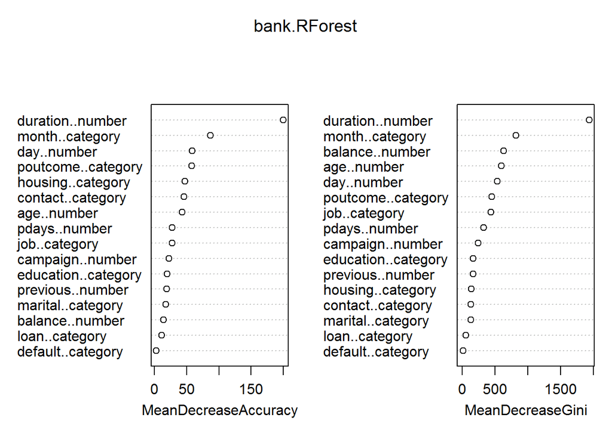

```r
varImpPlot(bank.RForest)
```

```r
actual <- bank_validate_caret$y..category
bank_predicted <- predict(bank.RForest, newdata=bank_validate_caret, type="class")
bank_results.matrix.rf <- confusionMatrix(bank_predicted, actual, positive="yes")
print(bank_results.matrix.rf)
```

```
## Confusion Matrix and Statistics
##
##           Reference
## Prediction   no  yes
##        no  7724  570
##        yes  260  487
##
##                Accuracy : 0.9082
##                  95% CI : (0.9021, 0.9141)
##     No Information Rate : 0.8831
##     P-Value [Acc > NIR] : 9.052e-15
##
##                   Kappa : 0.4906
##  Mcnemar's Test P-Value : < 2.2e-16
##
##             Sensitivity : 0.46074
##             Specificity : 0.96743
##          Pos Pred Value : 0.65194
##          Neg Pred Value : 0.93128
##              Prevalence : 0.11691
##          Detection Rate : 0.05387
##    Detection Prevalence : 0.08262
##       Balanced Accuracy : 0.71409
##
##        'Positive' Class : yes
##
```

## Recommendation

Both decision trees and the random forest method show that the duration of the previous contact to the customer is the most predictive of customers that subscribed to term deposits. This could be due to the fact that the more time you have the client on the call, the more details that can be given about term deposits. The first thing for Homebank to target is keeping the customers on the phone for at least 518 minutes. The logistic regression model found that the most important predictor of customer’s subscribing to a term deposit was the outcome of the prior marketing campaign. If the outcome of the prior marketing campaign was a success than customers were 10 times more likely to subscribe to a term deposit. Hometown Bank should create focused marketing campaigns about term deposits in order to educate their customers on the benefits of them and then follow this up by contacting their customers afterward.